# Magnimind Academy Fullstack Data Science Career Track Data Exploration Capstone Project

## Objectives

Hi All! You are learning a lot in a short span of time. It is now the time to test your data exploration skills with this capstone!

In this notebook, you're going to apply the skills you've been learning, bridging the gap towards the *slightly* messier work that data scientists do with actual datasets!

Here’s the mystery we’re going to solve: *which boroughs of London have seen the greatest increase in housing prices, on average, over the last two decades?*

A borough is just a fancy word for district. You may be familiar with the five boroughs of New York… well, there are 32 boroughs within Greater London [(here's some info for the curious)](https://en.wikipedia.org/wiki/London_boroughs). Some of them are more desirable areas to live in, and the data will reflect that with a greater rise in housing prices.

*In this notebook, we'll just give you the skeleton of a project, the brief and the data. It's up to you to play around with it and see what you can find out! Good luck! If you struggle, feel free to ask for help; the more independent work you do, the better it is for your learning!*

This challenge will make use of Data Exploration with Python skills.

## The Data Science Pipeline

When you feel done with your investigations, look back over what you've accomplished, and prepare a quick presentation of your findings.

Data Science is magical. In this case study, you'll get to apply some complex machine learning algorithms. But as [David Spiegelhalter](https://www.youtube.com/watch?v=oUs1uvsz0Ok) reminds us, there is no substitute for simply **taking a really, really good look at the data.** Sometimes, this is all we need to answer our question.

Data Science projects generally adhere to the four stages of Data Science Pipeline:

1. Sourcing and loading
2. Cleaning, transforming, and visualizing
3. Modeling
4. Evaluating and concluding

### 1. Sourcing and Loading

Any Data Science project kicks off by importing *pandas*. The documentation of this wonderful library can be found [here](https://pandas.pydata.org/). As you've seen, pandas is conveniently connected to the [Numpy](http://www.numpy.org/) and [Matplotlib](https://matplotlib.org/) libraries.

#### 1.1. Importing Libraries

```python
# Let's import the pandas, numpy libraries as pd, and np respectively.
import pandas as pd
import numpy as np



# Load the pyplot collection of functions from matplotlib, as plt
from matplotlib import pyplot as plt
```

#### 1.2. Loading the data

Your data comes from the [London Datastore](https://data.london.gov.uk/): a free, open-source data-sharing portal for London-oriented datasets.

```python
# First, make a variable called url_LondonHousePrices, and assign it the following link, enclosed in quotation-marks as a string:
# https://data.london.gov.uk/download/uk-house-price-index/70ac0766-8902-4eb5-aab5-01951aaed773/UK%20House%20price%20index.xls

url_LondonHousePrices = "https://data.london.gov.uk/download/uk-house-price-index/70ac0766-8902-4eb5-aab5-01951aaed773/UK%20House%20price%20index.xls"

# The dataset we're interested in contains the Average prices of the houses, and is actually on a particular sheet of the Excel file.
# As a result, we need to specify the sheet name in the read_excel() method.
# Put this data into a variable called properties.
properties = pd.read_excel(url_LondonHousePrices, sheet_name='Average price', index_col= None)

properties.head(10)
```

|  | Unnamed: 0 | City of London | Barking & Dagenham | Barnet | Bexley | Brent | Bromley | Camden | Croydon | Ealing | ... | NORTH WEST | YORKS & THE HUMBER | EAST MIDLANDS | WEST MIDLANDS | EAST OF ENGLAND | LONDON | SOUTH EAST | SOUTH WEST | Unnamed: 47 | England |
| --- | --- | --- | --- | --- | --- | --- | --- | --- | --- | --- | --- | --- | --- | --- | --- | --- | --- | --- | --- | --- | --- |
| 0 | NaT | E09000001 | E09000002 | E09000003 | E09000004 | E09000005 | E09000006 | E09000007 | E09000008 | E09000009 | ... | E12000002 | E12000003 | E12000004 | E12000005 | E12000006 | E12000007 | E12000008 | E12000009 | NaN | E92000001 |
| 1 | 1995-01-01 | 91448.98487 | 50460.2266 | 93284.51832 | 64958.09036 | 71306.56698 | 81671.47692 | 120932.8881 | 69158.16225 | 79885.89069 | ... | 43958.48001 | 44803.42878 | 45544.52227 | 48527.52339 | 56701.5961 | 74435.76052 | 64018.87894 | 54705.1579 | NaN | 53202.77128 |
| 2 | 1995-02-01 | 82202.77314 | 51085.77983 | 93190.16963 | 64787.92069 | 72022.26197 | 81657.55944 | 119508.8622 | 68951.09542 | 80897.06551 | ... | 43925.42289 | 44528.80721 | 46051.57066 | 49341.29029 | 56593.59475 | 72777.93709 | 63715.02399 | 54356.14843 | NaN | 53096.1549 |
| 3 | 1995-03-01 | 79120.70256 | 51268.96956 | 92247.52435 | 64367.49344 | 72015.76274 | 81449.31143 | 120282.2131 | 68712.44341 | 81379.86288 | ... | 44434.8681 | 45200.46775 | 45383.82395 | 49442.17973 | 56171.18278 | 73896.84204 | 64113.60858 | 53583.07667 | NaN | 53201.2843 |
| 4 | 1995-04-01 | 77101.20804 | 53133.50526 | 90762.87492 | 64277.66881 | 72965.63094 | 81124.41227 | 120097.899 | 68610.04641 | 82188.90498 | ... | 44267.7796 | 45614.34341 | 46124.23045 | 49455.93299 | 56567.89582 | 74455.28754 | 64623.22395 | 54786.01938 | NaN | 53590.8548 |
| 5 | 1995-05-01 | 84409.14932 | 53042.24852 | 90258.00033 | 63997.13588 | 73704.04743 | 81542.61561 | 119929.2782 | 68844.9169 | 82077.05525 | ... | 44223.61973 | 44830.98563 | 45878.00396 | 50369.66188 | 56479.80183 | 75432.02786 | 64530.36358 | 54698.83831 | NaN | 53678.24041 |
| 6 | 1995-06-01 | 94900.51244 | 53700.34831 | 90107.23471 | 64252.32335 | 74310.48167 | 82382.83435 | 121887.4625 | 69052.51103 | 81630.66181 | ... | 44112.96432 | 45392.63981 | 45679.99539 | 50100.43023 | 56288.94557 | 75606.24501 | 65511.008 | 54420.15939 | NaN | 53735.15475 |
| 7 | 1995-07-01 | 110128.0423 | 52113.12157 | 91441.24768 | 63722.70055 | 74127.03788 | 82898.52264 | 124027.5768 | 69142.48112 | 82352.2226 | ... | 44109.58764 | 45534.99864 | 46037.67312 | 49860.00809 | 57242.30186 | 75984.24079 | 65224.88465 | 54265.86368 | NaN | 53900.60633 |
| 8 | 1995-08-01 | 112329.4376 | 52232.19868 | 92361.31512 | 64432.60005 | 73547.0411 | 82054.37156 | 125529.8039 | 68993.42545 | 82706.65927 | ... | 44193.66583 | 45111.45939 | 45922.53585 | 49598.45969 | 56732.40547 | 75529.34488 | 64851.60429 | 54365.71495 | NaN | 53600.31975 |
| 9 | 1995-09-01 | 104473.1096 | 51471.61353 | 93273.12245 | 64509.54767 | 73789.54287 | 81440.43008 | 120596.8511 | 69393.50023 | 82011.08271 | ... | 44088.07696 | 44837.86023 | 45771.66321 | 49319.69715 | 56259.28635 | 74940.80872 | 64352.47119 | 54243.98694 | NaN | 53309.2331 |

10 rows × 49 columns

```python
Data_copy = properties
```

```python
# Use 3 decimal places in output display
pd.set_option("display.precision", 3)
```

### 2. Cleaning, transforming, and visualizing

This second stage is arguably the most important part of any Data Science project. The first thing to do is take a proper look at the data. Cleaning forms the majority of this stage, and can be done both before or after Transformation.

The end goal of data cleaning is to have tidy data. When data is tidy:

1. Each variable has a column.
2. Each observation forms a row.

Keep the end goal in mind as you move through this process, every step will take you closer.

**2.1. Exploring your data**

Think about your pandas functions for checking out a dataframe.

```python
Data_copy.columns
```

```
Index(['Unnamed: 0', 'City of London', 'Barking & Dagenham', 'Barnet',
       'Bexley', 'Brent', 'Bromley', 'Camden', 'Croydon', 'Ealing', 'Enfield',
       'Greenwich', 'Hackney', 'Hammersmith & Fulham', 'Haringey', 'Harrow',
       'Havering', 'Hillingdon', 'Hounslow', 'Islington',
       'Kensington & Chelsea', 'Kingston upon Thames', 'Lambeth', 'Lewisham',
       'Merton', 'Newham', 'Redbridge', 'Richmond upon Thames', 'Southwark',
       'Sutton', 'Tower Hamlets', 'Waltham Forest', 'Wandsworth',
       'Westminster', 'Unnamed: 34', 'Inner London', 'Outer London',
       'Unnamed: 37', 'NORTH EAST', 'NORTH WEST', 'YORKS & THE HUMBER',
       'EAST MIDLANDS', 'WEST MIDLANDS', 'EAST OF ENGLAND', 'LONDON',
       'SOUTH EAST', 'SOUTH WEST', 'Unnamed: 47', 'England'],
      dtype='object')
```

```python
Data_copy.duplicated().sum()
```

```
0
```

```python
Data_copy.isna().sum().sort_values(ascending=False)
```

```
Unnamed: 37             321
Unnamed: 47             321
Unnamed: 34             321
Outer London              0
Richmond upon Thames      0
Southwark                 0
Sutton                    0
Tower Hamlets             0
Waltham Forest            0
Wandsworth                0
Westminster               0
Inner London              0
Unnamed: 0                0
Newham                    0
NORTH EAST                0
NORTH WEST                0
YORKS & THE HUMBER        0
EAST MIDLANDS             0
WEST MIDLANDS             0
EAST OF ENGLAND           0
LONDON                    0
SOUTH EAST                0
SOUTH WEST                0
Redbridge                 0
Merton                    0
City of London            0
Lewisham                  0
Barking & Dagenham        0
Barnet                    0
Bexley                    0
Brent                     0
Bromley                   0
Camden                    0
Croydon                   0
Ealing                    0
Enfield                   0
Greenwich                 0
Hackney                   0
Hammersmith & Fulham      0
Haringey                  0
Harrow                    0
Havering                  0
Hillingdon                0
Hounslow                  0
Islington                 0
Kensington & Chelsea      0
Kingston upon Thames      0
Lambeth                   0
England                   0
dtype: int64
```

```python
# Displaying information for each column in DataFrame
Data_copy.info()
```

```
<class 'pandas.core.frame.DataFrame'>
Int64Index: 321 entries, 1 to 321
Data columns (total 49 columns):
 #   Column                Non-Null Count  Dtype
---  ------                --------------  -----
 0   Unnamed: 0            321 non-null    datetime64[ns]
 1   City of London        321 non-null    object
 2   Barking & Dagenham    321 non-null    object
 3   Barnet                321 non-null    object
 4   Bexley                321 non-null    object
 5   Brent                 321 non-null    object
 6   Bromley               321 non-null    object
 7   Camden                321 non-null    object
 8   Croydon               321 non-null    object
 9   Ealing                321 non-null    object
```

[output cut: 41 more lines]

```python
Data_copy.isnull().any(1).sum()
```

```
321
```

```python
Data_copy.isnull().any(0).sum()
```

[output not shown]

```python
Data_copy.isnull()
```

|  | Unnamed: 0 | City of London | Barking & Dagenham | Barnet | Bexley | Brent | Bromley | Camden | Croydon | Ealing | ... | NORTH WEST | YORKS & THE HUMBER | EAST MIDLANDS | WEST MIDLANDS | EAST OF ENGLAND | LONDON | SOUTH EAST | SOUTH WEST | Unnamed: 47 | England |
| --- | --- | --- | --- | --- | --- | --- | --- | --- | --- | --- | --- | --- | --- | --- | --- | --- | --- | --- | --- | --- | --- |
| 1 | False | False | False | False | False | False | False | False | False | False | ... | False | False | False | False | False | False | False | False | True | False |
| 2 | False | False | False | False | False | False | False | False | False | False | ... | False | False | False | False | False | False | False | False | True | False |
| 3 | False | False | False | False | False | False | False | False | False | False | ... | False | False | False | False | False | False | False | False | True | False |
| 4 | False | False | False | False | False | False | False | False | False | False | ... | False | False | False | False | False | False | False | False | True | False |
| 5 | False | False | False | False | False | False | False | False | False | False | ... | False | False | False | False | False | False | False | False | True | False |
| ... | ... | ... | ... | ... | ... | ... | ... | ... | ... | ... | ... | ... | ... | ... | ... | ... | ... | ... | ... | ... | ... |
| 317 | False | False | False | False | False | False | False | False | False | False | ... | False | False | False | False | False | False | False | False | True | False |
| 318 | False | False | False | False | False | False | False | False | False | False | ... | False | False | False | False | False | False | False | False | True | False |
| 319 | False | False | False | False | False | False | False | False | False | False | ... | False | False | False | False | False | False | False | False | True | False |
| 320 | False | False | False | False | False | False | False | False | False | False | ... | False | False | False | False | False | False | False | False | True | False |
| 321 | False | False | False | False | False | False | False | False | False | False | ... | False | False | False | False | False | False | False | False | True | False |

321 rows × 49 columns

```python
Data_copy.describe()
```

|  | Unnamed: 34 | Unnamed: 37 | Unnamed: 47 |
| --- | --- | --- | --- |
| count | 0.0 | 0.0 | 0.0 |
| mean | NaN | NaN | NaN |
| std | NaN | NaN | NaN |
| min | NaN | NaN | NaN |
| 25% | NaN | NaN | NaN |
| 50% | NaN | NaN | NaN |
| 75% | NaN | NaN | NaN |
| max | NaN | NaN | NaN |

```python
Data_copy.shape
```

[output not shown]

```python
Data_copy.isna().sum()
```

```
Unnamed: 0                0
City of London            0
Barking & Dagenham        0
Barnet                    0
Bexley                    0
Brent                     0
Bromley                   0
Camden                    0
Croydon                   0
Ealing                    0
Enfield                   0
Greenwich                 0
Hackney                   0
Hammersmith & Fulham      0
Haringey                  0
Harrow                    0
Havering                  0
Hillingdon                0
Hounslow                  0
Islington                 0
Kensington & Chelsea      0
Kingston upon Thames      0
Lambeth                   0
Lewisham                  0
Merton                    0
Newham                    0
Redbridge                 0
Richmond upon Thames      0
Southwark                 0
Sutton                    0
Tower Hamlets             0
Waltham Forest            0
Wandsworth                0
Westminster               0
Unnamed: 34             321
Inner London              0
Outer London              0
Unnamed: 37             321
NORTH EAST                0
NORTH WEST                0
YORKS & THE HUMBER        0
EAST MIDLANDS             0
WEST MIDLANDS             0
EAST OF ENGLAND           0
LONDON                    0
SOUTH EAST                0
SOUTH WEST                0
Unnamed: 47             321
England                   0
dtype: int64
```

```python
# Removing spaces in column names in sake of easy use
Data_copy.columns = Data_copy.columns.str.replace("\s+","_",regex=True)
```

```python
Data_copy.head(10)
```

|  | Unnamed:_0 | City_of_London | Barking_&_Dagenham | Barnet | Bexley | Brent | Bromley | Camden | Croydon | Ealing | ... | NORTH_WEST | YORKS_&_THE_HUMBER | EAST_MIDLANDS | WEST_MIDLANDS | EAST_OF_ENGLAND | LONDON | SOUTH_EAST | SOUTH_WEST | Unnamed:_47 | England |
| --- | --- | --- | --- | --- | --- | --- | --- | --- | --- | --- | --- | --- | --- | --- | --- | --- | --- | --- | --- | --- | --- |
| 1 | 1995-01-01 | 91448.985 | 50460.227 | 93284.518 | 64958.09 | 71306.567 | 81671.477 | 120932.888 | 69158.162 | 79885.891 | ... | 43958.48 | 44803.429 | 45544.522 | 48527.523 | 56701.596 | 74435.761 | 64018.879 | 54705.158 | NaN | 53202.771 |
| 2 | 1995-02-01 | 82202.773 | 51085.78 | 93190.17 | 64787.921 | 72022.262 | 81657.559 | 119508.862 | 68951.095 | 80897.066 | ... | 43925.423 | 44528.807 | 46051.571 | 49341.29 | 56593.595 | 72777.937 | 63715.024 | 54356.148 | NaN | 53096.155 |
| 3 | 1995-03-01 | 79120.703 | 51268.97 | 92247.524 | 64367.493 | 72015.763 | 81449.311 | 120282.213 | 68712.443 | 81379.863 | ... | 44434.868 | 45200.468 | 45383.824 | 49442.18 | 56171.183 | 73896.842 | 64113.609 | 53583.077 | NaN | 53201.284 |
| 4 | 1995-04-01 | 77101.208 | 53133.505 | 90762.875 | 64277.669 | 72965.631 | 81124.412 | 120097.899 | 68610.046 | 82188.905 | ... | 44267.78 | 45614.343 | 46124.23 | 49455.933 | 56567.896 | 74455.288 | 64623.224 | 54786.019 | NaN | 53590.855 |
| 5 | 1995-05-01 | 84409.149 | 53042.249 | 90258.0 | 63997.136 | 73704.047 | 81542.616 | 119929.278 | 68844.917 | 82077.055 | ... | 44223.62 | 44830.986 | 45878.004 | 50369.662 | 56479.802 | 75432.028 | 64530.364 | 54698.838 | NaN | 53678.24 |
| 6 | 1995-06-01 | 94900.512 | 53700.348 | 90107.235 | 64252.323 | 74310.482 | 82382.834 | 121887.462 | 69052.511 | 81630.662 | ... | 44112.964 | 45392.64 | 45679.995 | 50100.43 | 56288.946 | 75606.245 | 65511.008 | 54420.159 | NaN | 53735.155 |
| 7 | 1995-07-01 | 110128.042 | 52113.122 | 91441.248 | 63722.701 | 74127.038 | 82898.523 | 124027.577 | 69142.481 | 82352.223 | ... | 44109.588 | 45534.999 | 46037.673 | 49860.008 | 57242.302 | 75984.241 | 65224.885 | 54265.864 | NaN | 53900.606 |
| 8 | 1995-08-01 | 112329.438 | 52232.199 | 92361.315 | 64432.6 | 73547.041 | 82054.372 | 125529.804 | 68993.425 | 82706.659 | ... | 44193.666 | 45111.459 | 45922.536 | 49598.46 | 56732.405 | 75529.345 | 64851.604 | 54365.715 | NaN | 53600.32 |
| 9 | 1995-09-01 | 104473.11 | 51471.614 | 93273.122 | 64509.548 | 73789.543 | 81440.43 | 120596.851 | 69393.5 | 82011.083 | ... | 44088.077 | 44837.86 | 45771.663 | 49319.697 | 56259.286 | 74940.809 | 64352.471 | 54243.987 | NaN | 53309.233 |
| 10 | 1995-10-01 | 108038.118 | 51513.758 | 92567.385 | 64529.937 | 73264.054 | 81862.161 | 117458.492 | 68934.612 | 80522.661 | ... | 43109.994 | 44309.999 | 45154.72 | 49597.936 | 55240.289 | 74302.08 | 64125.806 | 54264.606 | NaN | 52844.621 |

10 rows × 49 columns

**2.2. Cleaning the data**

You might find you need to transpose your dataframe, check out what its row indexes are, and reset the index. You also might find you need to assign the values of the first row to your column headings . (Hint: recall the .columns feature of DataFrames, as well as the iloc[] method).

Don't be afraid to use StackOverflow for help with this.

```python
# Drop first row which makes hard to work on data and it does not such affect

Data_copy.drop(0,inplace=True)
```

**2.3. Cleaning the data (part 2)**

You might we have to **rename** a couple columns. How do you do this? The clue's pretty bold...

```python
Data_copy.columns
```

[output not shown]

```python
# Rename date column
Data_copy.rename(columns={'Unnamed:_0':'Date'},inplace = True)
```

```python
Data_copy
```

|  | Date | Barking_&_Dagenham | Barnet | Bexley | Brent | Bromley | Camden | Croydon | Ealing | Enfield | ... | Merton | Newham | Redbridge | Richmond_upon_Thames | Southwark | Sutton | Tower_Hamlets | Waltham_Forest | Wandsworth | Westminster |
| --- | --- | --- | --- | --- | --- | --- | --- | --- | --- | --- | --- | --- | --- | --- | --- | --- | --- | --- | --- | --- | --- |
| 1 | 1995-01-01 | 50460.227 | 93284.518 | 64958.09 | 71306.567 | 81671.477 | 120932.888 | 69158.162 | 79885.891 | 72514.691 | ... | 82070.613 | 53539.319 | 72189.584 | 109326.125 | 67885.203 | 71536.974 | 59865.19 | 61319.449 | 88559.044 | 133025.277 |
| 2 | 1995-02-01 | 51085.78 | 93190.17 | 64787.921 | 72022.262 | 81657.559 | 119508.862 | 68951.095 | 80897.066 | 73155.197 | ... | 79982.749 | 53153.883 | 72141.626 | 111103.039 | 64799.065 | 70893.209 | 62318.534 | 60252.122 | 88641.017 | 131468.31 |
| 3 | 1995-03-01 | 51268.97 | 92247.524 | 64367.493 | 72015.763 | 81449.311 | 120282.213 | 68712.443 | 81379.863 | 72190.441 | ... | 80661.683 | 53458.264 | 72501.355 | 107325.474 | 65763.297 | 70306.838 | 63938.677 | 60871.085 | 87124.815 | 132260.342 |
| 4 | 1995-04-01 | 53133.505 | 90762.875 | 64277.669 | 72965.631 | 81124.412 | 120097.899 | 68610.046 | 82188.905 | 71442.922 | ... | 79990.543 | 54479.754 | 72228.603 | 106875 | 63073.621 | 69411.944 | 66233.194 | 60971.397 | 87026.002 | 133370.204 |
| 5 | 1995-05-01 | 53042.249 | 90258.0 | 63997.136 | 73704.047 | 81542.616 | 119929.278 | 68844.917 | 82077.055 | 70630.78 | ... | 80873.986 | 55803.96 | 72366.641 | 107707.68 | 64420.499 | 69759.22 | 66432.858 | 61494.169 | 86518.059 | 133911.112 |
| ... | ... | ... | ... | ... | ... | ... | ... | ... | ... | ... | ... | ... | ... | ... | ... | ... | ... | ... | ... | ... | ... |
| 317 | 2021-05-01 | 312430.653 | 533319.35 | 361919.178 | 506917.307 | 464872.548 | 811080.363 | 391236.913 | 508368.502 | 418235.579 | ... | 540692.29 | 380125.62 | 451935.951 | 701319.953 | 507543.074 | 395317.852 | 438160.387 | 476898.285 | 600170.42 | 908209.321 |
| 318 | 2021-06-01 | 317234.735 | 541296.783 | 364464.187 | 514055.899 | 470431.417 | 814571.246 | 393198.407 | 507915.956 | 419803.094 | ... | 541278.331 | 382971.011 | 455605.548 | 698800.896 | 507753.747 | 396832.698 | 441463.011 | 474203.82 | 602200.028 | 888342.854 |
| 319 | 2021-07-01 | 319549.93 | 536012.669 | 366451.639 | 528684.055 | 466447.004 | 906099.2 | 389730.086 | 515141.329 | 421158.795 | ... | 544610.4 | 366701.669 | 461489.598 | 719159.046 | 519188.469 | 401044.143 | 459966.726 | 493007.748 | 602540.242 | 922331.022 |
| 320 | 2021-08-01 | 322496.375 | 544558.807 | 373547.295 | 533696.39 | 473570.356 | 921525.014 | 393245.781 | 515422.283 | 433986.209 | ... | 559114.797 | 379482.69 | 470113.184 | 736113.028 | 534447.284 | 401378.723 | 466570.526 | 502104.81 | 614932.295 | 1016725.048 |
| 321 | 2021-09-01 | 329287.292 | 533093.293 | 375156.155 | 542095.334 | 483955.024 | 895902.435 | 391878.875 | 525536.486 | 440813.079 | ... | 555225.54 | 365357.143 | 480339.944 | 735675.219 | 536755.525 | 415227.665 | 440846.736 | 505389.186 | 599124.413 | 965766.355 |

321 rows × 33 columns

```python
# Added a month column to dataframe so that processing data related to month will be easy
Data_copy['month'] = pd.DatetimeIndex(Data_copy['Date']).month

m = Data_copy.pop('month')

Data_copy.insert(1,'month',m)
```

```python
# Added a year column to dataframe so that processing data related to year will be easy

Data_copy['Year'] = pd.DatetimeIndex(Data_copy['Date']).year
y = Data_copy.pop('Year')
y
Data_copy.insert(1,'Year',y)
```

```python
Data_copy
```

|  | Date | Year | month | Barking_&_Dagenham | Barnet | Bexley | Brent | Bromley | Camden | Croydon | ... | Merton | Newham | Redbridge | Richmond_upon_Thames | Southwark | Sutton | Tower_Hamlets | Waltham_Forest | Wandsworth | Westminster |
| --- | --- | --- | --- | --- | --- | --- | --- | --- | --- | --- | --- | --- | --- | --- | --- | --- | --- | --- | --- | --- | --- |
| 1 | 1995-01-01 | 1995 | 1 | 50460.227 | 93284.518 | 64958.09 | 71306.567 | 81671.477 | 120932.888 | 69158.162 | ... | 82070.613 | 53539.319 | 72189.584 | 109326.125 | 67885.203 | 71536.974 | 59865.19 | 61319.449 | 88559.044 | 133025.277 |
| 2 | 1995-02-01 | 1995 | 2 | 51085.78 | 93190.17 | 64787.921 | 72022.262 | 81657.559 | 119508.862 | 68951.095 | ... | 79982.749 | 53153.883 | 72141.626 | 111103.039 | 64799.065 | 70893.209 | 62318.534 | 60252.122 | 88641.017 | 131468.31 |
| 3 | 1995-03-01 | 1995 | 3 | 51268.97 | 92247.524 | 64367.493 | 72015.763 | 81449.311 | 120282.213 | 68712.443 | ... | 80661.683 | 53458.264 | 72501.355 | 107325.474 | 65763.297 | 70306.838 | 63938.677 | 60871.085 | 87124.815 | 132260.342 |
| 4 | 1995-04-01 | 1995 | 4 | 53133.505 | 90762.875 | 64277.669 | 72965.631 | 81124.412 | 120097.899 | 68610.046 | ... | 79990.543 | 54479.754 | 72228.603 | 106875 | 63073.621 | 69411.944 | 66233.194 | 60971.397 | 87026.002 | 133370.204 |
| 5 | 1995-05-01 | 1995 | 5 | 53042.249 | 90258.0 | 63997.136 | 73704.047 | 81542.616 | 119929.278 | 68844.917 | ... | 80873.986 | 55803.96 | 72366.641 | 107707.68 | 64420.499 | 69759.22 | 66432.858 | 61494.169 | 86518.059 | 133911.112 |
| ... | ... | ... | ... | ... | ... | ... | ... | ... | ... | ... | ... | ... | ... | ... | ... | ... | ... | ... | ... | ... | ... |
| 317 | 2021-05-01 | 2021 | 5 | 312430.653 | 533319.35 | 361919.178 | 506917.307 | 464872.548 | 811080.363 | 391236.913 | ... | 540692.29 | 380125.62 | 451935.951 | 701319.953 | 507543.074 | 395317.852 | 438160.387 | 476898.285 | 600170.42 | 908209.321 |
| 318 | 2021-06-01 | 2021 | 6 | 317234.735 | 541296.783 | 364464.187 | 514055.899 | 470431.417 | 814571.246 | 393198.407 | ... | 541278.331 | 382971.011 | 455605.548 | 698800.896 | 507753.747 | 396832.698 | 441463.011 | 474203.82 | 602200.028 | 888342.854 |
| 319 | 2021-07-01 | 2021 | 7 | 319549.93 | 536012.669 | 366451.639 | 528684.055 | 466447.004 | 906099.2 | 389730.086 | ... | 544610.4 | 366701.669 | 461489.598 | 719159.046 | 519188.469 | 401044.143 | 459966.726 | 493007.748 | 602540.242 | 922331.022 |
| 320 | 2021-08-01 | 2021 | 8 | 322496.375 | 544558.807 | 373547.295 | 533696.39 | 473570.356 | 921525.014 | 393245.781 | ... | 559114.797 | 379482.69 | 470113.184 | 736113.028 | 534447.284 | 401378.723 | 466570.526 | 502104.81 | 614932.295 | 1016725.048 |
| 321 | 2021-09-01 | 2021 | 9 | 329287.292 | 533093.293 | 375156.155 | 542095.334 | 483955.024 | 895902.435 | 391878.875 | ... | 555225.54 | 365357.143 | 480339.944 | 735675.219 | 536755.525 | 415227.665 | 440846.736 | 505389.186 | 599124.413 | 965766.355 |

321 rows × 35 columns

**2.4.Transforming the data**

You might need to **melt** your DataFrame here.

```python
# Reshape dataframe to work on data easier
Data_copy
mdata = pd.melt(Data_copy,id_vars=['Date','Year','month'],var_name="London_Boroughs",value_name="Price")

mdata.info()
mdata
```

```
<class 'pandas.core.frame.DataFrame'>
RangeIndex: 10272 entries, 0 to 10271
Data columns (total 5 columns):
 #   Column           Non-Null Count  Dtype
---  ------           --------------  -----
 0   Date             10272 non-null  datetime64[ns]
 1   Year             10272 non-null  int64
 2   month            10272 non-null  int64
 3   London_Boroughs  10272 non-null  object
 4   Price            10272 non-null  float64
dtypes: datetime64[ns](1), float64(1), int64(2), object(1)
memory usage: 401.4+ KB
```

|  | Date | Year | month | London_Boroughs | Price |
| --- | --- | --- | --- | --- | --- |
| 0 | 1995-01-01 | 1995 | 1 | Barking_&_Dagenham | 5.046e+04 |
| 1 | 1995-02-01 | 1995 | 2 | Barking_&_Dagenham | 5.109e+04 |
| 2 | 1995-03-01 | 1995 | 3 | Barking_&_Dagenham | 5.127e+04 |
| 3 | 1995-04-01 | 1995 | 4 | Barking_&_Dagenham | 5.313e+04 |
| 4 | 1995-05-01 | 1995 | 5 | Barking_&_Dagenham | 5.304e+04 |
| ... | ... | ... | ... | ... | ... |
| 10267 | 2021-05-01 | 2021 | 5 | Westminster | 9.082e+05 |
| 10268 | 2021-06-01 | 2021 | 6 | Westminster | 8.883e+05 |
| 10269 | 2021-07-01 | 2021 | 7 | Westminster | 9.223e+05 |
| 10270 | 2021-08-01 | 2021 | 8 | Westminster | 1.017e+06 |
| 10271 | 2021-09-01 | 2021 | 9 | Westminster | 9.658e+05 |

10272 rows × 5 columns

Remember to make sure your column data types are all correct. Average prices, for example, should be floating point numbers...

```python
# price data type chamge to folat
mdata['Price'] = mdata['Price'].astype('float')
```

**2.5. Cleaning the data (part 3)**

Do we have an equal number of observations in the ID, Average Price, Month, and London Borough columns? Remember that there are only 32 London Boroughs. How many entries do you have in that column?

Check out the contents of the London Borough column, and if you find null values, get rid of them however you see fit.

```python
# # Deleting non-related columns in Dataframe
# Since there only 32 London Boroughs, the rest needs to be removed as follow
Data_copy.drop(['Inner_London', 'Outer_London', 'NORTH_EAST',
       'NORTH_WEST', 'YORKS_&_THE_HUMBER', 'EAST_MIDLANDS', 'WEST_MIDLANDS',
       'EAST_OF_ENGLAND', 'LONDON', 'SOUTH_EAST', 'SOUTH_WEST', 'City_of_London','England'], axis=1,inplace=True)

# Deleting columns whoes all values are NaN
Data_copy.drop(['Unnamed:_34','Unnamed:_37', 'Unnamed:_47'],axis=1,inplace=True)
```

[output not shown]

```python
mdata[mdata.Price>1000000].head(144)
```

|  | Date | Year | month | London_Boroughs | Price |
| --- | --- | --- | --- | --- | --- |
| 5987 | 2012-06-01 | 2012 | 6 | Kensington_&_Chelsea | 1.031e+06 |
| 5988 | 2012-07-01 | 2012 | 7 | Kensington_&_Chelsea | 1.033e+06 |
| 5989 | 2012-08-01 | 2012 | 8 | Kensington_&_Chelsea | 1.043e+06 |
| 5990 | 2012-09-01 | 2012 | 9 | Kensington_&_Chelsea | 1.058e+06 |
| 5991 | 2012-10-01 | 2012 | 10 | Kensington_&_Chelsea | 1.077e+06 |
| 5992 | 2012-11-01 | 2012 | 11 | Kensington_&_Chelsea | 1.072e+06 |
| 5993 | 2012-12-01 | 2012 | 12 | Kensington_&_Chelsea | 1.045e+06 |
| 5994 | 2013-01-01 | 2013 | 1 | Kensington_&_Chelsea | 1.068e+06 |
| 5995 | 2013-02-01 | 2013 | 2 | Kensington_&_Chelsea | 1.061e+06 |
| 5996 | 2013-03-01 | 2013 | 3 | Kensington_&_Chelsea | 1.076e+06 |
| 5997 | 2013-04-01 | 2013 | 4 | Kensington_&_Chelsea | 1.043e+06 |
| 5998 | 2013-05-01 | 2013 | 5 | Kensington_&_Chelsea | 1.087e+06 |
| 5999 | 2013-06-01 | 2013 | 6 | Kensington_&_Chelsea | 1.122e+06 |
| 6000 | 2013-07-01 | 2013 | 7 | Kensington_&_Chelsea | 1.160e+06 |
| 6001 | 2013-08-01 | 2013 | 8 | Kensington_&_Chelsea | 1.189e+06 |
| 6002 | 2013-09-01 | 2013 | 9 | Kensington_&_Chelsea | 1.218e+06 |
| 6003 | 2013-10-01 | 2013 | 10 | Kensington_&_Chelsea | 1.173e+06 |
| 6004 | 2013-11-01 | 2013 | 11 | Kensington_&_Chelsea | 1.169e+06 |
| 6005 | 2013-12-01 | 2013 | 12 | Kensington_&_Chelsea | 1.154e+06 |
| 6006 | 2014-01-01 | 2014 | 1 | Kensington_&_Chelsea | 1.205e+06 |
| 6007 | 2014-02-01 | 2014 | 2 | Kensington_&_Chelsea | 1.198e+06 |
| 6008 | 2014-03-01 | 2014 | 3 | Kensington_&_Chelsea | 1.210e+06 |
| 6009 | 2014-04-01 | 2014 | 4 | Kensington_&_Chelsea | 1.231e+06 |
| 6010 | 2014-05-01 | 2014 | 5 | Kensington_&_Chelsea | 1.263e+06 |
| 6011 | 2014-06-01 | 2014 | 6 | Kensington_&_Chelsea | 1.298e+06 |
| 6012 | 2014-07-01 | 2014 | 7 | Kensington_&_Chelsea | 1.346e+06 |
| 6013 | 2014-08-01 | 2014 | 8 | Kensington_&_Chelsea | 1.347e+06 |
| 6014 | 2014-09-01 | 2014 | 9 | Kensington_&_Chelsea | 1.344e+06 |
| 6015 | 2014-10-01 | 2014 | 10 | Kensington_&_Chelsea | 1.334e+06 |
| 6016 | 2014-11-01 | 2014 | 11 | Kensington_&_Chelsea | 1.365e+06 |

[output cut: 114 more lines]

**2.6. Visualizing the data**

To visualize the data, why not subset on a particular London Borough? Maybe do a line plot of Month against Average Price?

```python
import seaborn as sns
import matplotlib_inline
```

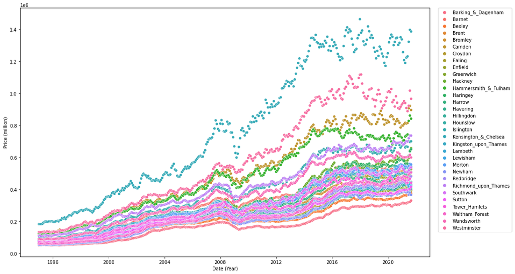

```python
# Plotting Lonodn Boroughs house prices changes over years

plt.figure(figsize=(16,10))

sns.scatterplot(mdata.Date,mdata.Price,data=mdata, hue ='London_Boroughs')
plt.legend(bbox_to_anchor=(1.02, 1), loc='upper left', borderaxespad=0)

# Set x-axis label
plt.xlabel('Date (Year)')
# Set y-axis label
plt.ylabel('Price (million)')
```

To limit the number of data points you have, you might want to extract the year from every month value your *Month* column.

To this end, you *could* apply a *lambda function*. Your logic could work as follows:

1. look through the `Month` column
2. extract the year from each individual value in that column
3. store that corresponding year as separate column.

Whether you go ahead with this is up to you. Just so long as you answer our initial brief: which boroughs of London have seen the greatest house price increase, on average, over the past two decades?

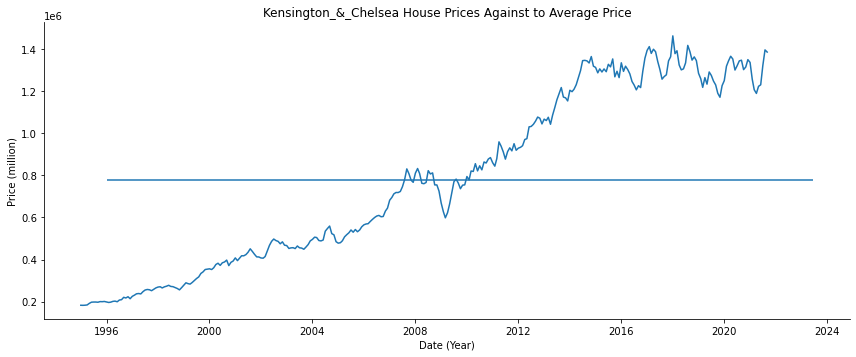

```python
#
# Average house price over years for Kensington_&_Chelsea
mean = mdata[mdata.London_Boroughs =='Kensington_&_Chelsea'].Price.mean()

# Plottting Average house price channges over years for Kensington_&_Chelsea against to average price
sns.relplot(
    data= mdata[mdata.London_Boroughs =='Kensington_&_Chelsea'], kind="line",
    x="Date", y="Price",
aspect=2.4
).set(
    title="Kensington_&_Chelsea House Prices Against to Average Price",
    ylabel='Price (million)',
    xlabel='Date (Year)')

plt.hlines(mean,9500,19521,label='Ave House Prices')
```

**3. Modeling**

Consider creating a function that will calculate a ratio of house prices, comparing the price of a house in 2018 to the price in 1998.

Consider calling this function create_price_ratio.

You'd want this function to:

1. Take a filter of dfg, specifically where this filter constrains the London_Borough, as an argument. For example, one admissible argument should be: dfg[dfg['London_Borough']=='Camden'].
2. Get the Average Price for that Borough, for the years 1998 and 2018.
3. Calculate the ratio of the Average Price for 1998 divided by the Average Price for 2018.
4. Return that ratio.

Once you've written this function, you ultimately want to use it to iterate through all the unique London_Boroughs and work out the ratio capturing the difference of house prices between 1998 and 2018.

Bear in mind: you don't have to write a function like this if you don't want to. If you can solve the brief otherwise, then great!

```python
Camden = mdata[mdata['London_Boroughs']=='Camden']
```

```python
# Calculating average price changes from 1998 to 2018

def create_price_ratio():
    Camden['1998']=np.where(Camden['Date'].between('1/1/1998','12/1/1998'),'start','end')
    mean_1998 = Camden[Camden['1998']=='start'].Price.mean()
    Camden['2018']=np.where(Camden['Date'].between('1/1/2018','12/1/2018'),'start','end')
    mean_2018 =Camden[Camden['2018']=='start'].Price.mean()

    return (mean_1998/mean_2018)*100

create_price_ratio()
```

```
20.26197350325254
```

### 4. Conclusion

What can you conclude? Type out your conclusion below.

Look back at your notebook. Think about how you might summarize what you have done, and prepare a quick presentation on it to your mentor at your next meeting.

We hope you enjoyed this practical project. It should have consolidated your data hygiene and pandas skills by looking at a real-world problem involving just the kind of dataset you might encounter as a budding data scientist. Congratulations, and looking forward to seeing you at the next step in the course!

**Short Summary**

- From the data set, it is clear that iin 2009 the house prices decreases and then it increases again. Sharp deacreases in 2009 is most probably because of real estate crisis happened in the USA.
- Another observation is that house prices are not stable after 2016